[figure not shown]

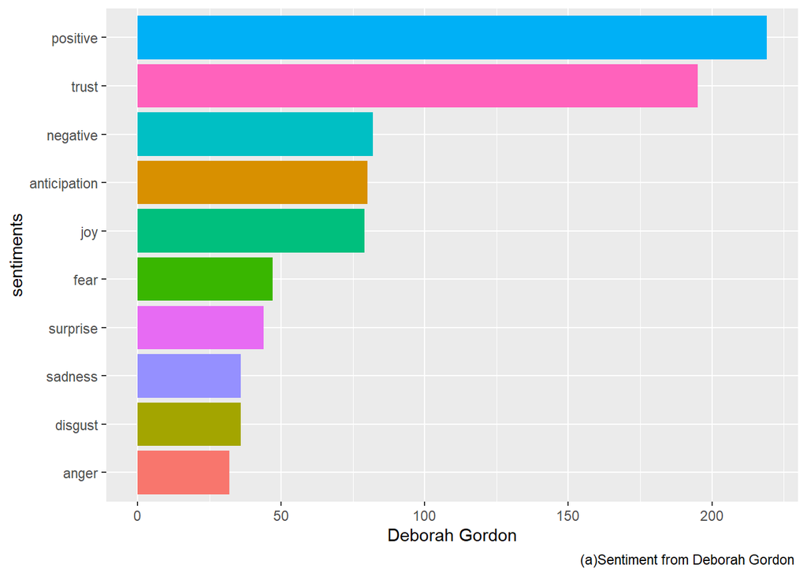

## Results

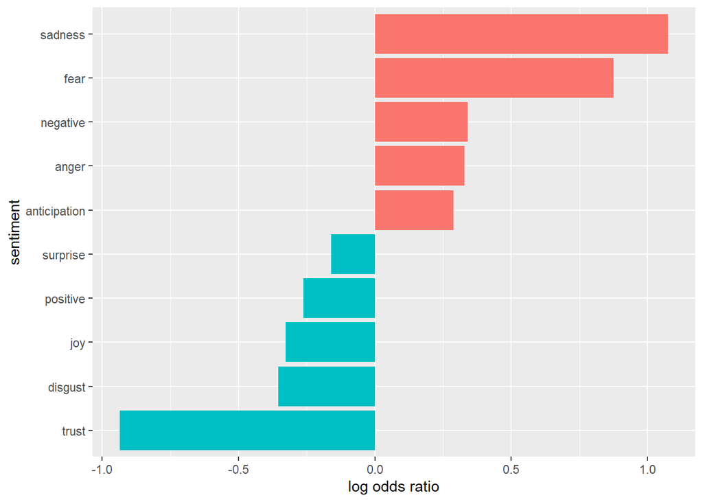

## Discussion

From the Global Environment , it can be seen that there are a list of observable variables under some of the functions and objects that i had to study and analyse. The data from Catherine showed a little difference in the observable variable when compared to Deborah’s. While comparing for the word frequencies of both speakers, i noticed that at a max.overlap of less than 93, it had much underlying max overlaps which halted my work from knitting to html, this may be as a result of the so many used words used in the ted talk. Much works can be done on these data sets depending on what other information we are trying to get out of them, personally, i believe that using other sentimental analysis lexicon like the ‘bing’, ‘AFINN’ lexicons either in a two ways approach or in a one way approach as i have used, there will be bound to be more useful information to be derived from them.